# Regulatory Elements in Neurodegenerative Diseases: Overlap with Human GWAS Risk Loci

Felix L Struebing

2/26/2018

Setting libraries:

```r
options(stringsAsFactors = F)
library(tidyverse)
library(DT)
library(rtracklayer)
library(annotables)
library(GenomicRanges)
library(tidygenomics)
library(Biostrings)
library(GenomicFeatures)
library(mogene20sttranscriptcluster.db)
library(BSgenome.Mmusculus.UCSC.mm10)
```

# Introduction

Regulatory Elements (REs), also called cis-REs, are DNA sequences to which a regulatory molecule (e.g. a transcription Factor or a microRNA) can bind. In order for binding to take place, chromatin must be in an open configuration (PMID 26661887, PMC5642610). We can leverage this fact to predict REs that have a known association with disease or gene transcription in regard to cell type-specific biological function.  
For the identification of REs that are functionally associated with AD, we use publically accessible high-throughput open chromatin assays from various sources:

1. Neuronal subtypes  
   [Epigenomic Signatures of Neuronal Diversity in the Mammalian Brain](https://www.ncbi.nlm.nih.gov/pubmed/26087164), PMID 26087164  
   Details: ATAC-Seq of different subtypes of **neurons** in C57BL/6-129SV mice. Cell types used: Parvalbumin (fast spiking interneurons), VIP-expressing interneurons, and excitatory pyramidal neurons (Camk2a), all isolated from Neocortex. We chose **PV neurons** and **excitatory neurons** only, as these are the cre-drivers we have here. We downloaded bigwig files (sub100nt filtered versions).  
   GEO: https://www.ncbi.nlm.nih.gov/geo/query/acc.cgi?acc=GSE63137  
   GEO format and alignment: bigwig files (bed peaks are too large), mm10
2. Astrocytes  
   [Core pathway mutations induce de-differentiation of murine astrocytes into glioblastoma stem cells that are sensitive to radiation but resistant to temozolomide](https://www.ncbi.nlm.nih.gov/pubmed/26826202), PMID 26826202  
   Details: FAIRE-Seq from isolated C57BL/6 **astrocytes**.  
   GEO: https://www.ncbi.nlm.nih.gov/geo/query/acc.cgi?acc=GSE73262  
   GEO format and alignment: bigwig of raw FAIRE signal, mm9
3. Microglia  
   [An environment-dependent transcriptional network specifies human microglia identity](https://www.ncbi.nlm.nih.gov/pubmed/28546318)  
   Details: C57BL/6 whole brain lysates with FACS-isolated **microglia**, and compared an in vivo with an ex vivo condition. GEO: https://www.ncbi.nlm.nih.gov/geo/query/acc.cgi?acc=GSE89960  
   GEO format and alignment: bed file, mm10
4. ENCODE files / bulk tissue  
   These are preprocessed peak (.bed) files from the ENCODE project, mapped to mm10.  
   Source; C57BL/6 **cerebellum adult**, downloaded fold-change over control .bigwig for 2 biological replicates: https://www.encodeproject.org/experiments/ENCSR554JQP/  
   Source; C57BL/6 **frontal cortex adult**, downloaded fold-change over control *.bigwig for 2 biological replicates: https://www.encodeproject.org/experiments/ENCSR889WQX/
5. Dentate Gyrus  
   [Neuronal activity modifies the chromatin accessibility landscape in the adult brain.](https://www.ncbi.nlm.nih.gov/pubmed/28166220), PMID 28166220  
   Details: This article analyzed open chromatin regions in the microdissected DG of 8 week-old C57BL/6 mice via ATAC-Seq at different timepoints either before (E0) or X hours after synchronous neuronal activation (EX). Data are available as precalled GEO datasets or as raw data in the SRA. The authors claim that their microdisscetion approach yields 90% **granular cells**. We could use this data to define chromatin footprints of unstimulated and stimulated hippocampal neurons.  
   GEO: [E0, E1, E4](https://www.ncbi.nlm.nih.gov/geo/query/acc.cgi?acc=GSE82010), [E24](https://www.ncbi.nlm.nih.gov/geo/query/acc.cgi?acc=GSE86367)  
   GEO format and alignment: bed file, mm9 (MACS)

# Analysis

## Import public open chromatin data

### 1. PV interneurons + Camk2a neurons

The precalled peaks were somewhat too wide - we downloaded bigwig files, converted to bedGraph, then called peaks on those using MACS2 and the following parameters (the cutoff was verified to be just above background by visual inspection of bigwig files): cutoff -c 3, min length -l 100

```r
# files = list.files('data/GSE63137_neuron_subtypes_ATAC/', full.names = T)
# neurons = map(files, import.bed)
# neurons[[2]]@elementMetadata$origin = 'PV_neurons'
# neurons[[2]]@elementMetadata$itemRgb = 'darkorange3'
# neurons[[1]]@elementMetadata$origin = 'Camk2a_neurons'
# neurons[[1]]@elementMetadata$itemRgb = 'goldenrod1'
# neurons = c(neurons[[1]], neurons[[2]])
files = list.files('data/GSE63137_neuron_subtypes_ATAC/recalled', pattern = '.bed', full.names = T)
files.gr = map(files, read_delim, delim = '\t', skip = 1, col_names = c('seqnames', 'start', 'end', 'peak', 'score', 'A', 'B', 'C', 'D', 'E'))
files.gr = map(files.gr, makeGRangesFromDataFrame)
PV_neurons = Reduce(intersect, list(files.gr[[3]], files.gr[[4]]))
PV_neurons@elementMetadata$origin = 'PV_neurons'
PV_neurons@elementMetadata$itemRgb = 'darkorange3'
Camk2a_neurons = Reduce(intersect, list(files.gr[[1]], files.gr[[2]]))
Camk2a_neurons@elementMetadata$origin = 'Camk2a_neurons'
Camk2a_neurons@elementMetadata$itemRgb = 'goldenrod1'
neurons = c(PV_neurons, Camk2a_neurons)
length(neurons)
```

```
## [1] 189825
```

### 2. Astrocytes

Files were only available as bigwig genome graphs. In order to call peaks, we need to convert the bigwigs into bedgraphs first and then run MACS2 on them. The following commands were used for this purpose:

–> convert bw to bedg: `felice@MacBook-Pro:~/Desktop/AD_loci_for_cloning/bin$ ./bigWigToBedGraph ../data/GSE73262_astrocytes_FAIRE/GSM1889812_AC1-FAIRE.bw AC1_FAIRE.bedGraph`

–> call peaks using MACS2: `macs2 bdgpeakcall -i AC1_FAIRE.bedGraph -l 100 -c 8 -o AC1_peaks.bed`

Import and lift over to mm10:

```r
files = list.files('data/GSE73262_astrocytes_FAIRE/', pattern = 'bed$', full.names = T)
files.gr = map(files, read_delim, delim = '\t', skip = 1, col_names = c('seqnames', 'start', 'end', 'peak', 'score', 'A', 'B', 'C', 'D', 'E'))
files.gr = map(files.gr, makeGRangesFromDataFrame)
chain = import.chain('data/mm9ToMm10.over.chain')
astrocytes = Reduce(intersect, files.gr) %>%
  liftOver(., chain)
astrocytes = unlist(astrocytes)
astrocytes@elementMetadata$origin = 'astrocytes'
astrocytes@elementMetadata$itemRgb = 'dodgerblue2'
length(astrocytes)
```

```
## [1] 28461
```

### 3. Microglia

```r
files = list.files('data/GSE89960_microglia_ATAC/', full.names = T)
microglia = map(files, import.bed)
names(microglia) = c('microglia_exvivo', 'microglia_invitro')
microglia[[1]]@elementMetadata$origin = 'microglia_exvivo'
microglia[[1]]@elementMetadata$itemRgb = 'chartreuse1'
microglia[[2]]@elementMetadata$origin = 'microglia_invitro'
microglia[[2]]@elementMetadata$itemRgb = 'chartreuse3'
microglia = c(microglia[[1]], microglia[[2]])
mcols(microglia) = DataFrame(mcols(microglia)[3], mcols(microglia)[4])
rm(files, files.gr)
length(microglia)
```

```
## [1] 203651
```

### 4. ENCODE

For the adult C57BL/6 ATAC-seq files, bigwigs (fold changes over control) were downloaded for both replicates and converted to bedGraph. Peaks were called with MACS2 on these bedGraph files with a cutoff so that there were approx. 50k peaks in each replicate.

Merge and reduce replicates:

#### CEREBELLUM

```r
cerebellum = map(list.files('data/ENCODE_mm10_cerebellum_ATAC/', pattern = '.bed', full.names = T, recursive = F), read_delim, delim = '\t', col_names = F, skip = 1) %>% map(., makeGRangesFromDataFrame, seqnames.field = 'X1', start.field = 'X2', end.field = 'X3') %>% Reduce(intersect, .)
cerebellum@elementMetadata$origin = 'cerebellum'
cerebellum@elementMetadata$itemRgb = 'magenta3'
length(cerebellum)
```

```
## [1] 30557
```

#### FRONTAL CORTEX

```r
frontalCortex = map(list.files('data/ENCODE_mm10_frontalCortex_ATAC/', pattern = '.bed', full.names = T, recursive = F), read_delim, delim = '\t', col_names = F, skip = 1) %>% map(., makeGRangesFromDataFrame, seqnames.field = 'X1', start.field = 'X2', end.field = 'X3') %>% Reduce(intersect, .)
frontalCortex@elementMetadata$origin = 'frontalCortex'
frontalCortex@elementMetadata$itemRgb = 'firebrick1'
length(frontalCortex)
```

```
## [1] 34873
```

### 5. Dentate Gyrus

```r
files = list.files('data/GSE82010_DG_neurons_ATAC/', full.names = T)
files.gr = map(files, import.bed)
names(files.gr) = str_sub(files, start = 32, end = -8)
# merge replicates
E0 = Reduce(intersect, files.gr[1:4])
#export.bed(E0, 'E0.bed')
E1 = Reduce(intersect, files.gr[5:8])
#export.bed(E1, 'E1.bed')
E4 = Reduce(intersect, files.gr[9:12])
#export.bed(E4, 'E4.bed')
common = Reduce(intersect, list(E0, E1, E4)) # merges REs that are active in all conditions
common@elementMetadata$condition = 'common_REs'
#export.bed(common, 'common.bed')
stim = c(E1, E4)
stim_specific = stim[!stim %over% common]
stim_specific@elementMetadata$condition = 'stim_specific_REs'
#export.bed(stim_specific, 'stim_specific.bed')
unstim_specific = E0[!E0 %over% stim_specific]
unstim_specific = unstim_specific[!unstim_specific %over% common]
unstim_specific@elementMetadata$condition = 'unstim_specific_REs'
#export.bed(unstim_specific, 'unstim_specific.bed')

# store the results
granularDG = c(common, stim_specific, unstim_specific)
granularDG@elementMetadata$origin = paste0('granularDG', '_', granularDG@elementMetadata$condition)
mcols(granularDG) = granularDG@elementMetadata$origin
granularDG@elementMetadata$itemRgb = 'darkorchid3'
#export.bed(granularDG, 'granularDG.bed')
rm(E0, E1, E4, common, stim, stim_specific, unstim_specific)
# lift everything over to mm10
dentateGyrus = liftOver(granularDG, chain)
dentateGyrus = unlist(dentateGyrus)
names(mcols(dentateGyrus)) = c('origin', 'itemRgb')
rm(granularDG)
length(dentateGyrus)
```

```
## [1] 46743
```

## Annotating REs with closest gene

Define a function for this:

```r
annotateREs = function(x) {
  mouseGenes = (annotables::grcm38) %>% dplyr::select(symbol, chr, start, end, biotype) %>% makeGRangesFromDataFrame(., keep.extra.columns = T)
  seqlevelsStyle(mouseGenes) = 'UCSC'
  closeGenes = nearest(x, unstrand(mouseGenes))
  closeGenes[is.na(closeGenes)] = 53728
  x@elementMetadata$closestGene = mouseGenes[closeGenes]@elementMetadata$symbol
  distanceGenes = distance(x, mouseGenes[closeGenes])
  x@elementMetadata$distanceToClosest = distanceGenes
  x@elementMetadata$closestGene[is.na(mcols(x)$distanceToClosest)] = 'none_found'
  x
}
```

## Combining REs

```r
regelements = GRangesList('astrocytes' = astrocytes, 'pvNeurons' = PV_neurons, 'camk2aNeurons' = Camk2a_neurons,  'microglia' = microglia, 'frontalCortex' = frontalCortex, 'cerebellum' = cerebellum, 'dentateGyrus' = dentateGyrus)
regelements = endoapply(regelements, annotateREs)
names(regelements)
```

```
## [1] "astrocytes"    "pvNeurons"     "camk2aNeurons" "microglia"
## [5] "frontalCortex" "cerebellum"    "dentateGyrus"
```

```r
#save(regelements, file = 'combined_REs_mm10.Rdata')
```

Is the distance to the closes gene roughly the same for each RE?

```r
lapply(regelements, function(x) {summary(x@elementMetadata$distanceToClosest)})
```

```
## $astrocytes
##    Min. 1st Qu.  Median    Mean 3rd Qu.    Max.
##       0       0       0    9158    3073  744352
##
## $pvNeurons
##    Min. 1st Qu.  Median    Mean 3rd Qu.    Max.
##       0       0       0   13445    5266  973623
##
## $camk2aNeurons
##    Min. 1st Qu.  Median    Mean 3rd Qu.    Max.
##       0       0       0   18762   11552  966661
##
## $microglia
##    Min. 1st Qu.  Median    Mean 3rd Qu.    Max.    NA's
##       0       0       0    9049    4265  870171     106
##
## $frontalCortex
##    Min. 1st Qu.  Median    Mean 3rd Qu.    Max.    NA's
##       0       0       0   15742    8330  950829      11
##
## $cerebellum
##    Min. 1st Qu.  Median    Mean 3rd Qu.    Max.    NA's
##       0       0       0    7841     116  897642      18
##
## $dentateGyrus
##    Min. 1st Qu.  Median    Mean 3rd Qu.    Max.
##       0       0       0   14470    5360  996477
```

What is the top closest gene?

```r
lapply(regelements, function(x) {x@elementMetadata %>% as.data.frame() %>% group_by(closestGene) %>% summarize(n = n(), mean_distance = mean(distanceToClosest, na.rm = T)) %>% arrange(-n)})
```

```
## $astrocytes
## # A tibble: 14,255 x 3
##    closestGene       n mean_distance
##    <chr>         <int>         <dbl>
##  1 Gm26804         163           0
##  2 Gm20388          98           0
##  3 Gm2619           55           0
##  4 4930467E23Rik    48        4313.
##  5 6820431F20Rik    47         444.
##  6 C230088H06Rik    34           0
##  7 Mid1             32          57.2
##  8 2610005L07Rik    31        5241.
##  9 Fgfr2            29         647.
## 10 Gm7760           27        3632.
## # ... with 14,245 more rows
##
## $pvNeurons
## # A tibble: 21,264 x 3
##    closestGene     n mean_distance
##    <chr>       <int>         <dbl>
##  1 Gm20388       101           0
##  2 Tenm2          80        1633.
##  3 Celf4          76         562.
##  4 Astn2          69         836.
##  5 Elmo1          69         316.
##  6 Pde4d          69        1541.
##  7 Ctnna3         67          18.0
##  8 Klhl29         66          59.9
##  9 Dpp6           60         204.
## 10 Gm37240        60           0
## # ... with 21,254 more rows
##
## $camk2aNeurons
## # A tibble: 23,698 x 3
##    closestGene     n mean_distance
##    <chr>       <int>         <dbl>
##  1 Gm20388       180          0
##  2 Tenm2         118       5918.
##  3 Ctnna2        116      11288.
##  4 Pde4d         102          6.54
```

[output cut: 56 more lines]

```
## $dentateGyrus
## # A tibble: 18,255 x 3
##    closestGene     n mean_distance
##    <chr>       <int>         <dbl>
##  1 Gm20388       100            0
##  2 Ctnna2         46         4818.
##  3 Gm37240        46            0
##  4 Pde4d          42            0
##  5 Magi2          41            0
##  6 Macrod2        39         2681.
##  7 Anks1b         35          986.
##  8 Csmd1          35         3678.
##  9 Tenm2          35         5089.
## 10 Fhit           34          997.
## # ... with 18,245 more rows
```

What is the width distribution of REs in each cell type?

```r
regelements = endoapply(regelements, function(x) {x[width(x) <= 2000]})
```

## RE width analysis

How many REs did this approach yield per cell type?

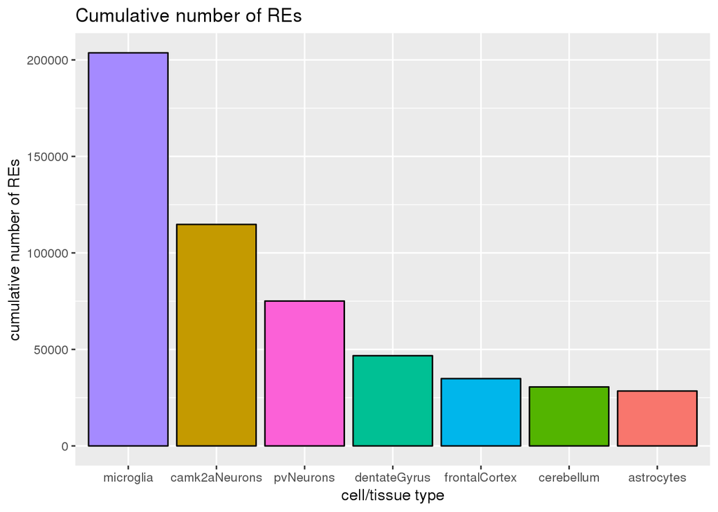

```r
sapply(regelements, length) %>% as.data.frame() %>% add_rownames(., 'tissue') %>%
  ggplot(aes(x = reorder(tissue, -`.`), y = `.`, fill = tissue)) +
  geom_col(color = 'black') +
  labs(x = 'cell/tissue type', y = 'cumulative number of REs', title = 'Cumulative number of REs') +
  scale_fill_discrete(guide = F)
```

What is the width of all REs per cell type, as a sum?

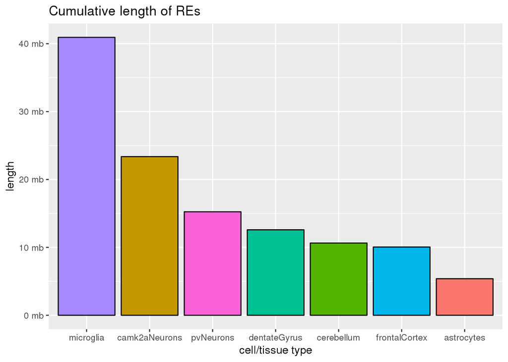

```r
sum(width(regelements)) %>% as.data.frame() %>% add_rownames(., 'tissue') %>%
  ggplot(aes(x = reorder(tissue, -`.`), y = `.`/1000000, fill = tissue)) +
  geom_col(color = 'black') +
  labs(x = 'cell/tissue type', y = 'length', title = 'Cumulative length of REs') +
  scale_fill_discrete(guide = F) +
  scale_y_continuous(label = scales::unit_format(unit = 'mb'))
```

Repeat distribution plot.

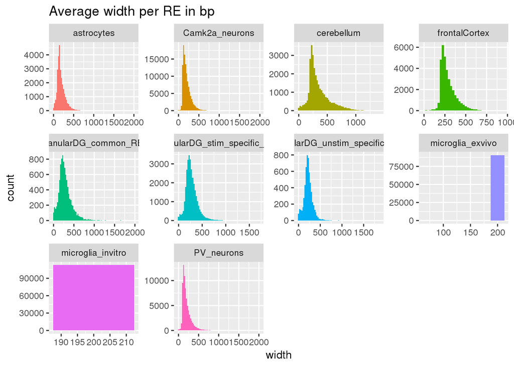

```r
unlist(regelements) %>%
  as.data.frame(row.names = NULL) %>%
  ggplot(aes(x = width, fill = origin)) +
  geom_histogram(binwidth = 25) +
  facet_wrap(~origin, scales = 'free') +
  scale_fill_discrete(guide = F) +
  labs(title = 'Average width per RE in bp')
```

Better one:

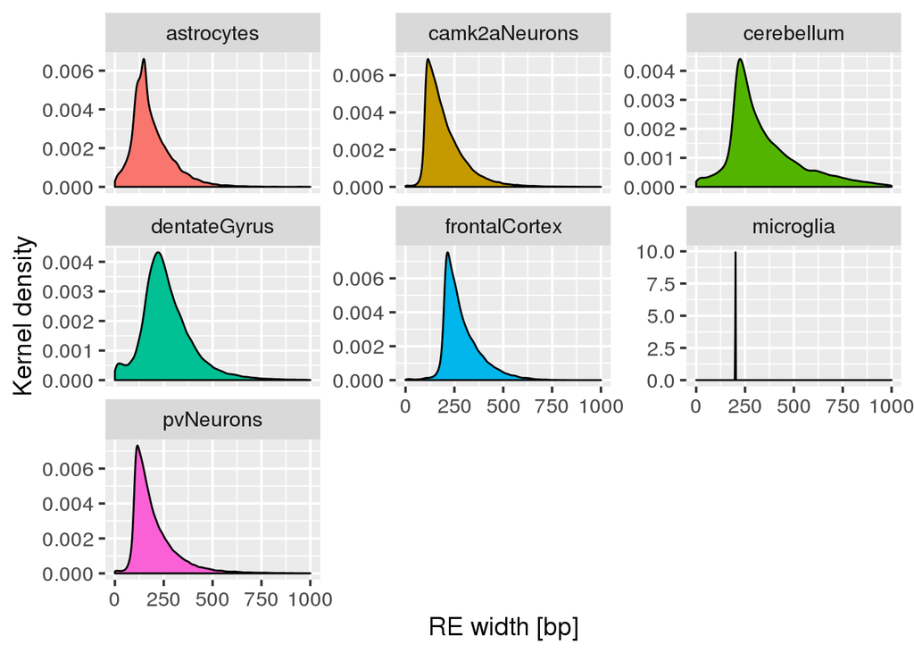

```r
regelements %>% as.data.frame() %>%
  #dplyr::filter(group_name != 'microglia' & width > 201) %>%
  ggplot(aes(x = width, fill = group_name)) +
  geom_density()+
  facet_wrap(~group_name, scales = 'free_y') +
  xlim(0, 1000) +
  scale_fill_discrete(guide = F) +
  labs(x = 'RE width [bp]', y = 'Kernel density') +
  theme_grey(base_size = 14)
```

### Common REs in all cell types

```r
strand(regelements) = '*'
commonreg = Reduce(intersect, regelements)
commonreg@elementMetadata$origin = 'common_REs'
commonreg@elementMetadata$itemRgb = 'honeydew4'
```

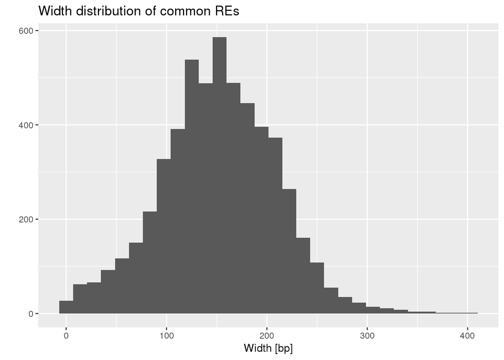

```r
qplot(x = width(commonreg)) + labs(x = 'Width [bp]', title = 'Width distribution of common REs')
```

### Export results

```r
bed = unlist(regelements)
bed.exp = bed
mcols(bed.exp) = DataFrame(
  name = mcols(bed.exp)$origin,
  score = 100,
  itemRgb = mcols(bed.exp)$itemRgb
)
export.bed(bed.exp, 'export/regelements_colored_by_celltype.bed')
```

## Human GWAS overlay

### Importing GWAS loci

Import the GWAS catalog file.

```r
files = list.files('data/GWAS_associations/', pattern = '.txt', full.names = T)
gwas_raw = map(files, read_delim, delim = '\t') %>%
  do.call(rbind, .) %>%
  unique()
#dplyr::filter(grepl('Schizo', `DISEASE/TRAIT`))
dim(gwas_raw)
```

```
## [1] 4072   34
```

Some stats for the GWAS associations.

```r
gwas_raw %>% group_by(`DISEASE/TRAIT`) %>% tally() %>% arrange(-n) %>% DT::datatable(.)
```

|  | DISEASE/TRAIT | n |
| --- | --- | --- |
| 1 | Schizophrenia | 1130 |
| 2 | Autism spectrum disorder or schizophrenia | 301 |
| 3 | Parkinson's disease | 229 |
| 4 | Alzheimer disease and age of onset | 203 |
| 5 | Amyotrophic lateral sclerosis (sporadic) | 183 |
| 6 | Late-onset Alzheimer's disease | 123 |
| 7 | Intraocular pressure | 87 |
| 8 | Amyotrophic lateral sclerosis | 80 |
| 9 | Alzheimer's disease | 76 |
| 10 | Alzheimer's disease (late onset) | 74 |

[output cut: 139 more lines]

```r
gwas_raw %>%
  group_by(CONTEXT) %>%
  tally() %>%
  arrange(-n) %>%
  DT::datatable(.)
```

|  | CONTEXT | n |
| --- | --- | --- |
| 1 | intron_variant | 2185 |
| 2 | intergenic_variant | 914 |
| 3 | upstream_gene_variant | 216 |
| 4 |  | 185 |
| 5 | downstream_gene_variant | 150 |
| 6 | non_coding_transcript_exon_variant | 109 |
| 7 | regulatory_region_variant | 98 |
| 8 | missense_variant | 79 |
| 9 | 3_prime_UTR_variant | 76 |
| 10 | synonymous_variant | 21 |

[output cut: 11 more lines]

### Extracting ancestries

#### Overview of which populations were included:

```r
removeWords = paste0('\\b(', paste0(c('case', 'cases', 'control', 'ancestry', 'of', 'individuals', 'founder', 'up', 'to', 'controls'), collapse = '|'), ')\\b')

gwas_raw %>%
  dplyr::select(`INITIAL SAMPLE SIZE`, SNPS) %>%
  mutate(ancestries = gsub(x = `INITIAL SAMPLE SIZE`, pattern = '[[:digit:]]', replacement = '', fixed = F)) %>%
  mutate(ancestries = gsub(x = ancestries, pattern = '[[:punct:]]', replacement = '', fixed = F)) %>%
  mutate(ancestries = gsub(x = ancestries, pattern = removeWords, replacement = '')) %>%
  group_by(ancestries) %>%
  tally() %>%
  arrange(-n)
# manually make a list of populations
```

#### Set ancestry based on regular expression search.

```r
okPops = paste0('\\b(', paste0(c('European', 'Ashkenazi', 'Hispanic', 'Japanese', 'Han', 'African', 'Korean', 'Israeli', 'Chinese', 'Finnish', 'Amish'), collapse = '|'), ')\\b')
gwas_anc = gwas_raw %>%
  mutate(hasAncestry = grepl(pattern = okPops, x = `INITIAL SAMPLE SIZE`)) %>%
  dplyr::filter(hasAncestry) %>%
  mutate(ancestry = str_extract(`INITIAL SAMPLE SIZE`, pattern = okPops))
```

How many SNPs are unique in the whole dataset vs the ancestry-filtered dataset?

```r
length(unique(gwas_raw$SNPS))
```

```
## [1] 3438
```

```r
length(unique(gwas_anc$SNPS))
```

```
## [1] 3141
```

```r
length(unique(gwas_raw$SNPS)) - length(unique(gwas_anc$SNPS))
```

```
## [1] 297
```

We will lose some informative SNPs if we account for ancestry in the LD block calculation. Missing values can be replaced with Europan ancestry.

```r
gwas_noAnc = gwas_raw %>%
  mutate(hasAncestry = grepl(pattern = okPops, x = `INITIAL SAMPLE SIZE`)) %>%
  dplyr::filter(!hasAncestry)
```

```r
gwas_anc %>% group_by(ancestry) %>% tally() %>% arrange(-n)
```

```
## # A tibble: 11 x 2
##    ancestry      n
##    <chr>     <int>
##  1 European   2339
##  2 Ashkenazi   662
##  3 Han         235
##  4 Chinese     228
##  5 African     181
##  6 Japanese     29
##  7 Amish        16
##  8 Finnish      13
##  9 Hispanic      3
## 10 Israeli       2
## 11 Korean        2
```

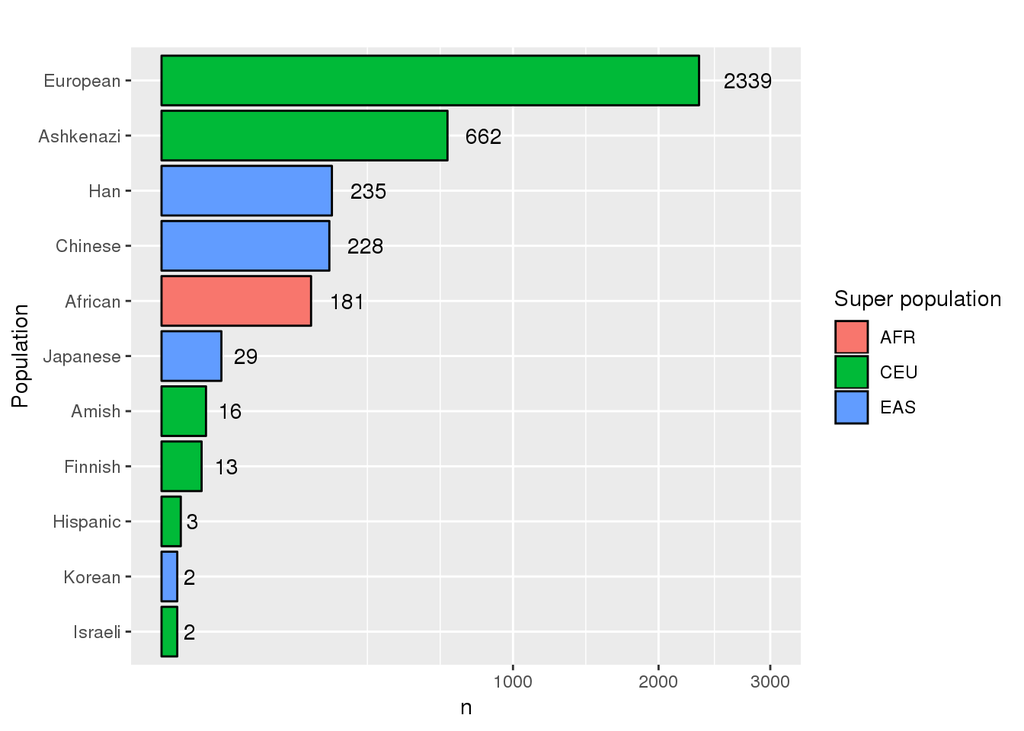

```r
gwas_anc %>% group_by(ancestry) %>% tally() %>%
  mutate(group = case_when(ancestry %in% c('European', 'Finnish', 'Hispanic', 'Ashkenazi', 'Israeli', 'Amish') ~ 'CEU',
                           ancestry %in% c('Han', 'Chinese', 'Japanese', 'Korean') ~ 'EAS',
                           ancestry %in% 'African' ~ 'AFR')) %>%
  ggplot(aes(x = reorder(ancestry, n), y = n, fill= group)) +
  geom_col(color = 'black') +
  coord_flip() +
  geom_text(aes(label = n), position = position_dodge(width = 1), hjust = -0.5) +
  scale_y_sqrt(limits = c(0, 3000)) +
  labs(title = '', x = 'Population', y = 'n', fill = 'Super population')
```

### Expanding human SNPs with LD interval

** EVAL FALSE**

```r
# data = gwas_noAnc %>%
#   dplyr::filter(grepl('rs', SNPS)) %>%
#   dplyr::filter(!grepl(';', SNPS))
#dplyr::slice(3000:3036)
gwas_anc %>%
  dplyr::filter(!SNPS %in% haplo$SNPS) %>%
  group_by(ancestry) %>%
  tally()

data = gwas_anc %>%
  dplyr::filter(!SNPS %in% haplo$SNPS) %>%
  dplyr::filter(ancestry == 'European' | ancestry == 'Finnish') %>%
  dplyr::filter(grepl('rs', SNPS) | grepl('chr', SNPS)) %>%
  dplyr::filter(!grepl(';', SNPS))
```

Temporary copy to clipboard:

```r
data = data$SNPS
clip <- pipe("pbcopy", "w")
write.table(data, file=clip, quote = F, row.names = F)
close(clip)
rm(data, clip)
```

** / EVAL FALSE **

We found LD intervals with the rAggr tool using an r^2 cutoff of 0.8. Respective population panels are given in the filename. Database used was 1000 Genomes Pilot Phase 3 hg19. Options were as follows: Max distance 500kb, min r^2 0.8, min MAF 0.1%.

```r
files = list.files('data/hapmaps/', pattern = 'GWAS', full.names = T)
haplogp = map(files, read.csv)
haplogp = do.call(rbind, haplogp)
haplo_sizes = haplogp %>%
  group_by(SNP1.Name) %>%
  tally() %>%
  unique() %>%
  filter(n >1)
```

```r
haplog = haplogp %>%
  group_by(SNP1.Name) %>%
  summarize(min_ld1 = min(SNP1.Pos), max_ld1 = max(SNP1.Pos), min_ld2 = min(SNP2.Pos), max_ld2 = max(SNP2.Pos),
            min_r2 = min(R.squared), min_dpr = min(D.), chr = SNP1.Chr[1], ancestry = Population[1])
```

Some LD intervals do not start with SNP1 but enclose SNP1 - resulting in pseudo-negative widths (This was the mistake made in earlier versions of this script.)

In what cases is SNP1 (the GWAS “reference SNP”) the starting point of the LD interval?

```r
haplog %>% dplyr::filter(min_ld1 == min_ld2)
```

```
## # A tibble: 893 x 9
##    SNP1.Name min_ld1 max_ld1 min_ld2 max_ld2 min_r2 min_dpr chr   ancestry
##    <chr>       <dbl>   <dbl>   <dbl>   <dbl>  <dbl>   <dbl> <chr> <chr>
##  1 rs100178…  1.73e8  1.73e8  1.73e8  1.73e8  1       1     2     CEU+FIN…
##  2 rs100182…  1.82e8  1.82e8  1.82e8  1.82e8  0.989   1.000 4     CEU+FIN…
##  3 rs100600…  1.19e7  1.19e7  1.19e7  1.19e7  1       1     5     ACB+ASW…
##  4 rs100696…  1.28e6  1.28e6  1.28e6  1.28e6  1       1     5     CEU+FIN…
##  5 rs101210…  3.53e7  3.53e7  3.53e7  3.53e7  1       1     9     CEU+FIN…
##  6 rs101236…  2.92e7  2.92e7  2.92e7  2.92e7  0.938   0.993 9     CEU+FIN…
##  7 rs101489…  8.95e5  8.95e5  8.95e5  8.95e5  1       1     20    CEU+FIN…
##  8 rs102115…  1.98e8  1.98e8  1.98e8  1.98e8  1       1     2     CEU+FIN…
##  9 rs102187…  4.18e7  4.18e7  4.18e7  4.18e7  0.923   0.986 1     CEU+FIN…
## 10 rs102334…  1.93e7  1.93e7  1.93e7  1.93e7  0.940   1.000 7     CEU+FIN…
## # ... with 883 more rows
```

Is SNP1 the reference (starting) SNP for all LDs?

```r
all(haplog$min_ld1 == haplog$max_ld1)
```

```
## [1] TRUE
```

Are all widths positive?

```r
all(haplog$max_ld2 >= haplog$min_ld1)
```

```
## [1] TRUE
```

How many SNPs did not result in an LD interval but are single bps?

```r
table(haplog$min_ld1 == haplog$max_ld2)
```

```
##
## FALSE  TRUE
##  2011   851
```

Extract LD intervals from this table:

```r
haplo = haplog %>%
  #dplyr::filter(min_ld1 != min_ld2) %>%
  dplyr::mutate(start_ld = case_when(
    min_ld2 > min_ld1 ~ min_ld1,
    min_ld2 < min_ld1 ~ min_ld2,
    min_ld2 == min_ld1 ~ min_ld1
  ),
  end_ld = max_ld2) %>%
  mutate(width = end_ld - start_ld) %>%
  mutate(SNPS = str_extract(SNP1.Name, pattern = '[^:]*'))
summary(haplo$width)
```

```
##    Min. 1st Qu.  Median    Mean 3rd Qu.    Max.
##       0    3207   23328   69586   80536  999318
```

Some SNPs do not have an interval:

```r
haplo %>% dplyr::filter(start_ld == end_ld)
```

```
## # A tibble: 511 x 13
##    SNP1.Name min_ld1 max_ld1 min_ld2 max_ld2 min_r2 min_dpr chr   ancestry
##    <chr>       <dbl>   <dbl>   <dbl>   <dbl>  <dbl>   <dbl> <chr> <chr>
##  1 rs100178…  1.73e8  1.73e8  1.73e8  1.73e8      1       1 2     CEU+FIN…
##  2 rs100600…  1.19e7  1.19e7  1.19e7  1.19e7      1       1 5     ACB+ASW…
##  3 rs100696…  1.28e6  1.28e6  1.28e6  1.28e6      1       1 5     CEU+FIN…
##  4 rs101210…  3.53e7  3.53e7  3.53e7  3.53e7      1       1 9     CEU+FIN…
##  5 rs101489…  8.95e5  8.95e5  8.95e5  8.95e5      1       1 20    CEU+FIN…
##  6 rs102115…  1.98e8  1.98e8  1.98e8  1.98e8      1       1 2     CEU+FIN…
##  7 rs102473…  1.35e8  1.35e8  1.35e8  1.35e8      1       1 7     CEU+FIN…
##  8 rs104700…  4.96e7  4.96e7  4.96e7  4.96e7      1       1 20    CEU+FIN…
##  9 rs105036…  2.00e7  2.00e7  2.00e7  2.00e7      1       1 8     CEU+FIN…
## 10 rs107469…  7.69e7  7.69e7  7.69e7  7.69e7      1       1 9     CDX+CHB…
## # ... with 501 more rows, and 4 more variables: start_ld <dbl>,
## #   end_ld <dbl>, width <dbl>, SNPS <chr>
```

```r
# test = haplo %>% dplyr::filter(width == 0)
# testpops = inner_join(test, gwas_raw, by = 'SNPS')
# haplopos = inner_join(haplo, gwas_raw, by = 'SNPS')
```

#### Width distribution

How big are the LD blocks?

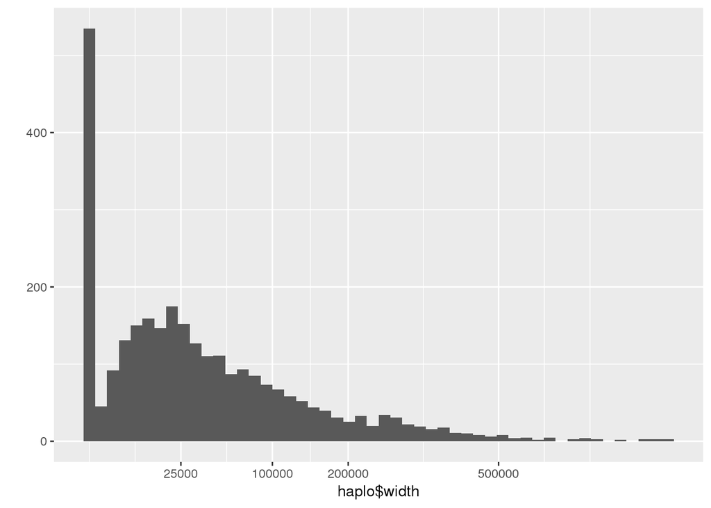

```r
qplot(haplo$width, bins = 50) + scale_x_sqrt(breaks = c(2500, 25000, 1e5, 2e5, 5e5))
```

We could force the SNPs for which an LD interval was not found to the median distribution. For those, the average LD width is about 25k. A paper reporting the average GWAS resolution based on imputation and WGS claims that 80% of all causal variants are within 33.5 kbp of the lead SNP: https://genomebiology.biomedcentral.com/articles/10.1186/s13059-017-1216-0

#### Fixing LD blocks for NAs

Determine LD intervals with width = 0 and extend these by a fixed value.

```r
haplomiss = haplo %>%
  dplyr::filter(width == 0) %>%
  dplyr::mutate(start_ld = min_ld1 - 17000, end_ld = min_ld1 + 17000) %>%
  mutate(width = end_ld - start_ld)
```

Merge both tables and retain only unique values.

```r
haplores = haplo %>%
  bind_rows(haplo, haplomiss) %>%
  dplyr::filter(width != 0) %>%
  unique()
length(haplores$SNPS)
```

```
## [1] 2862
```

```r
length(unique(haplores$SNPS))
```

```
## [1] 2850
```

Now check the width again:

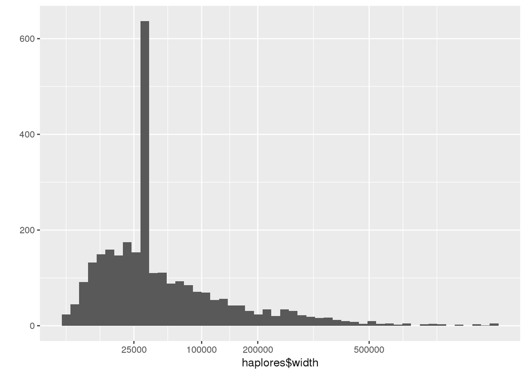

```r
qplot(haplores$width, bins = 50) + scale_x_sqrt(breaks = c(2500, 25000, 1e5, 2e5, 5e5))
```

```r
median(haplores$width)
```

```
## [1] 34000
```

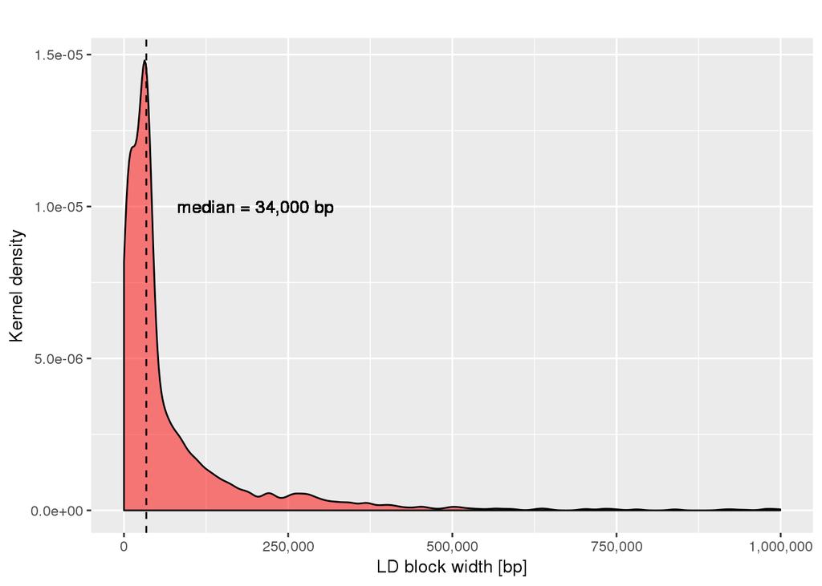

```r
library(scales)
haplores %>%
  ggplot(aes(x = width)) +
  geom_density(fill = 'red', alpha = .5) +
  geom_vline(aes(xintercept = median(width)), linetype = 'dashed') +
  geom_text(aes(x = 200000, y = 1e-5, label = 'median = 34,000 bp')) +
  scale_x_continuous(labels = comma) +
  scale_y_continuous() +
  labs(title = '', y = 'Kernel density', x = 'LD block width [bp]')
```

## Overlay mouse REs and human GWAS loci

### Lifting over hg19 to mm10

```r
gwas_anc = gwas_anc %>%
  dplyr::filter(SNPS %in% haplores$SNPS) %>%
  left_join(., haplores, by = 'SNPS') %>%
  unique()

#gwas_anc %>% dplyr::filter(`REPORTED GENE(S)` == 'LUZP2')

chain = import.chain('data/hg19ToMm10.over.chain')
gwas_mm10 = gwas_anc %>%
  dplyr::select(PUBMEDID, `DISEASE/TRAIT`, CHR_ID, start_ld, end_ld, min_r2, min_dpr, SNPS, CONTEXT, `P-VALUE`) %>%
  dplyr::filter(!is.na(CHR_ID)) %>%
  dplyr::mutate(CHR_ID = paste0('chr', CHR_ID)) %>%
  dplyr::filter(!grepl(';', CHR_ID)) %>%
  dplyr::mutate(name = `DISEASE/TRAIT`) %>%
  dplyr::mutate(name = gsub(x = name, pattern = ' ', replacement = '_')) %>%
  dplyr::mutate(score = `P-VALUE`) %>%
  dplyr::select(-`DISEASE/TRAIT`, -`P-VALUE`) %>%
  unique() %>%
  makeGRangesFromDataFrame(., seqnames.field = 'CHR_ID', start.field = 'start_ld', end.field = 'end_ld', keep.extra.columns = T) %>%
  liftOver(., chain)
# delete empty elements (no mouse equivalent)
table(elementNROWS(gwas_mm10) == 0)
```

```
##
## FALSE  TRUE
##  3067    89
```

```r
gwas_mm10 = gwas_mm10[!elementNROWS(gwas_mm10) == 0]
```

## Adding more genes

Certain genes have also been described to be differentially expressed in AD vs controls. We want to add possible regulatory elements for these genes to see how they are modulated in a disease situation.

### APP NL-G-F

From this publication: https://www.ncbi.nlm.nih.gov/pmc/articles/PMC5736730/

```r
genexpr = readxl::read_xlsx('data/gene_expression_APP-NL-G-F/41598_2017_17999_MOESM7_ESM.xlsx', skip = 1)
genexpr.gr = AnnotationDbi::select(mogene20sttranscriptcluster.db, keys = as.character(genexpr$`Affymetrix ID`), columns = c('CHR', 'CHRLOC', 'CHRLOCEND')) %>%
  mutate(chromosome = paste0('chr', CHR), start = abs(CHRLOC), end = abs(CHRLOCEND), strand = ifelse(CHRLOC<0, '-', '+')) %>%
  na.omit() %>%
  makeGRangesFromDataFrame(., seqnames.field = 'chromosome', start.field = 'start', end.field = 'end')
genexpr_prom = promoters(genexpr.gr, upstream = 2000)
genexpr = c(genexpr.gr, genexpr_prom)
```

### CK-p25

From Manolis Kellis Nature 2015 paper.

```r
files = readxl::read_excel('data/gene_expression_CKp25/filteredChanges_FDR005_foldChangeAboveAverage.xlsx') %>% arrange(`CK-p25 All__1`) %>% top_n(250, wt = -`CK-p25 All__1`)
library(TxDb.Mmusculus.UCSC.mm10.ensGene)
ckp25.gr = select(TxDb.Mmusculus.UCSC.mm10.ensGene, keys = files$`Ensembl ID`, columns = c('TXNAME', 'TXCHROM', 'TXSTART', 'TXEND'), keytype = 'GENEID') %>% dplyr::group_by(GENEID) %>% summarize(start = min(TXSTART), end = max(TXEND), seqnames = TXCHROM[1]) %>% na.omit() %>% makeGRangesFromDataFrame(.)
```

### Manual addition

Manually adding interesting gene regions based on literature search. All coordinates are **mm10**.

- *App* coordinates: chr16:84,934,252-85,235,670
- *Mapt* coordinates: chr11:104,213,728-104,333,970
- *Snca* (already in the panel, extending to promoter: chr6:60,819,536-60,842,627
- *Brca1* https://www.ncbi.nlm.nih.gov/pubmed/29042514: chr11:101,539,775-101,566,684
- *Bdnf*: chr2:109,604,220-109,743,192
- *Clu*: chr14:65,959,760-65,980,669

```r
app.gr = GRanges(seqnames = 'chr16', ranges = IRanges(84934300, 85235670))
mapt.gr = GRanges(seqnames = 'chr11', ranges = IRanges(104213800, 104333970))
snca.gr = GRanges(seqnames = 'chr6', ranges = IRanges(60819500, 60842600))
brca1.gr = GRanges(seqnames = 'chr11', ranges = IRanges(101539800, 101566650))
bdnf.gr = GRanges(seqnames = 'chr2', ranges = IRanges(109604220, 109743190))
clu.gr = GRanges(seqnames = 'chr14', ranges = IRanges(65959760, 65980670))
psen1 = GRanges(seqnames = 'chr12', ranges = IRanges(83674598, 83737947))
psen2 = GRanges(seqnames = 'chr1', ranges = IRanges(180213360, 180273694))
bace1 = GRanges(seqnames = 'chr9', ranges = IRanges(45823398, 45873979))
ncstn = GRanges(seqnames = 'chr1', ranges = IRanges(172062382, 172085833))
aph1a = GRanges(seqnames = 'chr3', ranges = IRanges(95869495, 95911636))
cd147 = GRanges(seqnames = 'chr10', ranges = IRanges(79693536, 79717967))
bace2 = GRanges(seqnames = 'chr16', ranges = IRanges(97350608, 97490082))
genexpr = c(genexpr, ckp25.gr, app.gr, mapt.gr, snca.gr, brca1.gr, bdnf.gr, clu.gr, psen1, psen2, bace1, ncstn, aph1a, cd147, bace2)
```

# Results

Final number of human GWAS association loci translated to mouse: 3067  
Final number of mouse REs: 534079  
Final number of mouse REs per cell type:

```r
sapply(split(bed, bed@elementMetadata$origin), length)
```

```
##                 Camk2a_neurons                     PV_neurons
##                         114752                          75064
##                     astrocytes                     cerebellum
##                          28445                          30557
##                  frontalCortex          granularDG_common_REs
##                          34873                           9371
##   granularDG_stim_specific_REs granularDG_unstim_specific_REs
##                          31545                           5821
##               microglia_exvivo              microglia_invitro
##                          90674                         112977
```

## GWAS overlapping REs

Make an informal data frame containing the all overlaps between REs and GWAS hits - *note that this will contain duplicated IDs, as multiple cell type-specific REs can overlap multiple GWAS hits*.

```r
gwas = unlist(gwas_mm10)
#gwas = gwas_mm10_fixed
ov = IRanges::findOverlaps(bed, gwas)
regsOfInterest = data.frame(
  chromosome = seqnames(bed[queryHits(ov)]),
  RE_start = start(bed[queryHits(ov)]),
  RE_end = end(bed[queryHits(ov)]),
  GWAS_start = start(gwas[subjectHits(ov)]),
  GWAS_end = end(gwas[subjectHits(ov)]),
  RE_origin = mcols(bed[queryHits(ov)])$origin,
  closest_gene = mcols(bed[queryHits(ov)])$closestGene,
  closest_gene_distance = mcols(bed[queryHits(ov)])$distanceToClosest,
  GWAS_trait = mcols(gwas[subjectHits(ov)])$name,
  GWAS_SNP = mcols(gwas[subjectHits(ov)])$SNPS,
  GWAS_context = mcols(gwas[subjectHits(ov)])$CONTEXT,
  GWAS_pval = mcols(gwas[subjectHits(ov)])$score,
  GWAS_PMID = mcols(gwas[subjectHits(ov)])$PUBMEDID
) %>%
  dplyr::mutate(RE_width = RE_end - RE_start)
```

How many gene symbols that were reported to be mapped in GWAS studies actually overlap mouse genes?

```r
gwas_raw_mapped = gwas_raw$MAPPED_GENE %>% str_split(., ' - ') %>% unlist(.) %>% str_split(., ', ') %>% unlist(.)
gwas_ann = annotateREs(gwas)
gwas_ann@elementMetadata$closestGene = toupper(gwas_ann@elementMetadata$closestGene)
length(unique(gwas_raw_mapped))
```

```
## [1] 3330
```

```r
length(unique(gwas_ann$closestGene))
```

```
## [1] 4795
```

```r
table(unique(gwas_ann$closestGene) %in% unique(gwas_raw_mapped))
```

```
##
## FALSE  TRUE
##  3677  1118
```

Make the GWAS data frame more unique for downstream analysis and bait ordering, as some REs are duplicated due to overlap with multiple GWAS_loci.

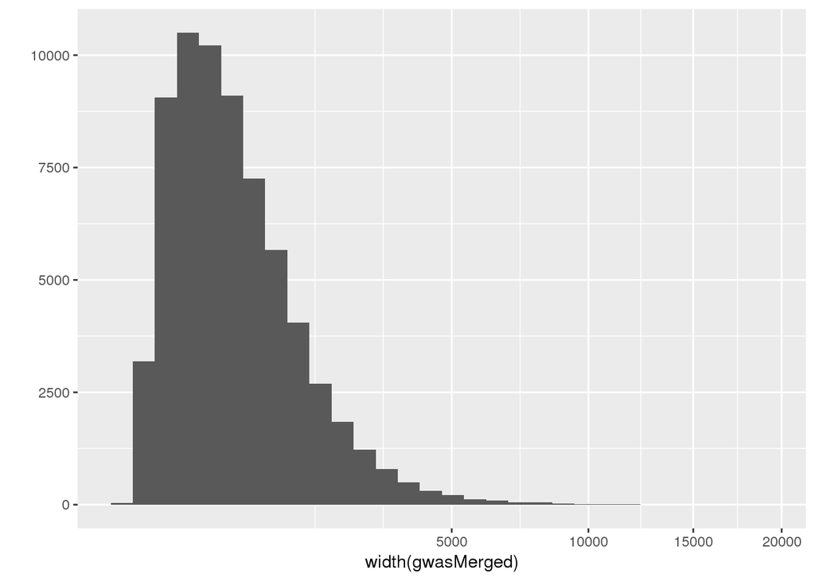

```r
mergeOverlapping = function(gr) {
  #gr = unlist(gwas_mm10)
  toMerge = as.tibble(gr) %>% dplyr::select(seqnames, start, end)
  #joined = genome_inner_join_closest(toMerge, toMerge) %>% dplyr::select(seqnames = seqnames.x, start = start.x, end = end.x) %>% unique() %>% makeGRangesFromDataFrame(.)
  joined = toMerge %>%
    group_by(seqnames) %>%
    arrange(start) %>%
    ungroup() %>%
    genome_cluster(., by = c('seqnames', 'start', 'end'), max_distance = 80) %>%
    group_by(cluster_id) %>%
    summarize(seqnames = seqnames[1], start = min(start), end = max(end)) %>%
    unique() %>%
    makeGRangesFromDataFrame(.)
  return(joined)
}
gwasMerged = mergeOverlapping(unlist(gwas_mm10))
qplot(width(gwasMerged)) + scale_x_sqrt()
```

```r
bedMerged = mergeOverlapping(bed)

summary(width(unlist(gwas_mm10)))
```

```
##    Min. 1st Qu.  Median    Mean 3rd Qu.    Max.
##    1.00   12.00   21.00   29.36   35.00 3473.00
```

```r
summary(width(gwasMerged))
```

```
##    Min. 1st Qu.  Median    Mean 3rd Qu.    Max.
##     1.0   192.0   464.0   766.8   987.0 19101.0
```

```r
summary(width(gwasMerged))
```

```
##    Min. 1st Qu.  Median    Mean 3rd Qu.    Max.
##     1.0   192.0   464.0   766.8   987.0 19101.0
```

```r
export.bed(unlist(gwas_mm10), 'export/gwas_UNmerged_regions_mm10.bed')
export.bed(gwasMerged, 'export/gwas_merged_regions_mm10.bed')
export.bed(genexpr, 'export/genexpr_merged_regions_mm10.bed')
```

## Merge GWAS and gene expression data

```r
# add the gene expression ranges to the gwasMerged object
bigRegions = c(gwasMerged, genexpr)
strand(bigRegions) = '*'
regsIntersection = intersect(bigRegions, bedMerged)
export.bed(regsIntersection, 'export/REs_of_interest_mm10.bed')
```

## Plot intersection of REs and GWAS / gene expr. data

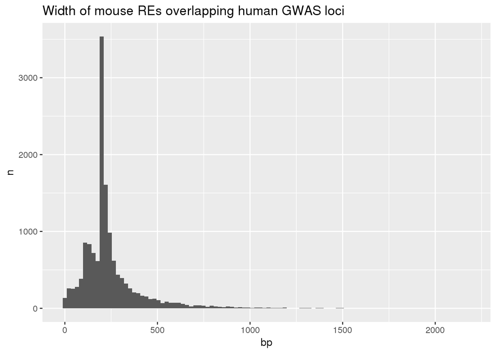

```r
qplot(width(regsIntersection), bins = 100) + labs(title = 'Width of mouse REs overlapping human GWAS loci', y = 'n',  x = 'bp')
```